# R workshop draft

keyla

2023-07-31

```r
data<-read.csv("FFB.Keyla.Group.csv")
library(ggplot2)
library(reshape2)
library(tidyverse)
library(dplyr)

names(data)[names(data) == "Condition...1..Unfamiliar.country.eats.familiar.food..2..unfamiliar.country.eats.unfamiliar.food.."] <- "unfamCountryfoodpair"

names(data)[names(data) =="Rating...1.Really.don.t.like..to.4.Really.like."]<-"ratings"

names(data)[names(data) =="Time...0..pre.test..1..post.test"]<-"prePosttest"

names(data)[names(data) =="PID...Participant.ID..4.lines.per.participants"]<-"pid"

names(data)[names(data) =="FoodFam...Which.type.of.food.children.saw.them.with..0..unfamiliar..1..familiar"]<-"FamUnfamFood"
data$GroupCountryFam<-as.factor(data$GroupCountryFam)
data$unfamCountryfoodpair<-as.factor(data$unfamCountryfoodpair)
data$prePosttest<-as.factor(data$prePosttest)
data$FamUnfamFood<-as.factor(data$FamUnfamFood)
```

## Overview

This report presents preliminary data analysis from a study conducted by the UCSB child Studies Lab. Basically this will report basic descriptive statistics as well as report tests of the following predictions:

1. Children will like people from America more than from Suriname
2. Children will like people who eat familiar foods more than people who eat unfamiliar foods +2.2 Children will like people from Suriname more after seeing them eat familiar foods rather than unfamiliar foods.
3. Liking will increase after learning that people eat familiar foods

## Prediction 1 Analysis

We can reject the null hypothesis, indicating that there is a significant association between country familiarity and general likability. In other words children liked kids from America more than kids from Suriname.

```r
#run one-way anova
p1 <-aov(ratings~GroupCountryFam+Error(pid),data=data)
#output result
summary(p1)
```

```
##
## Error: pid
##           Df Sum Sq Mean Sq F value Pr(>F)
## Residuals  1  5.773   5.773
##
## Error: Within
##                  Df Sum Sq Mean Sq F value Pr(>F)
## GroupCountryFam   1   71.3   71.27   120.5 <2e-16 ***
## Residuals       931  550.7    0.59
## ---
## Signif. codes:  0 '***' 0.001 '**' 0.01 '*' 0.05 '.' 0.1 ' ' 1
```

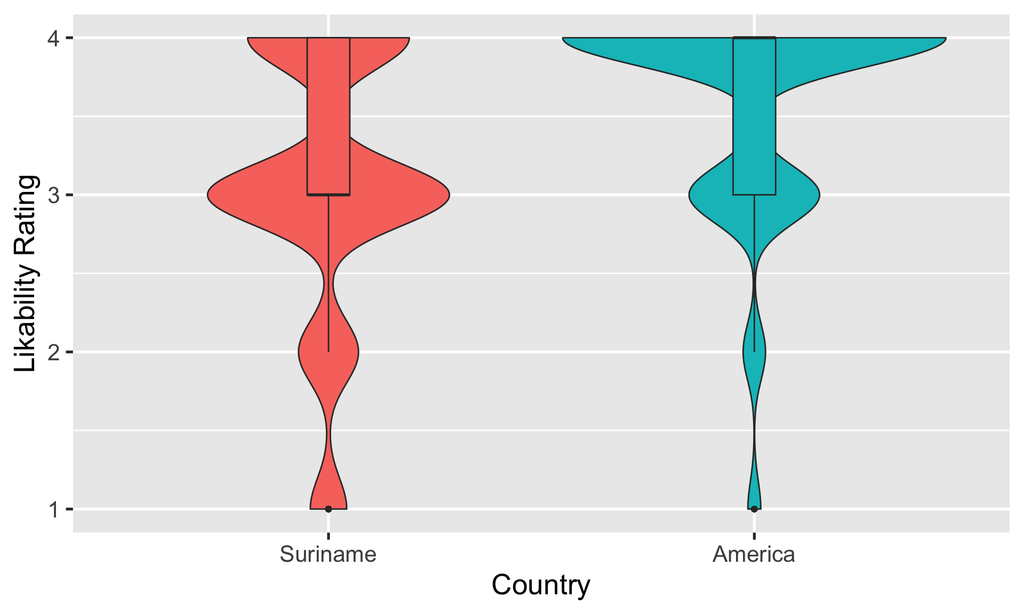

```r
plot1 <- ggplot(data = data,
                  aes(x = GroupCountryFam,
                      y = ratings,
                      fill =GroupCountryFam)) +
  labs(x = "Country", y = "Likability Rating") +
  scale_x_discrete(labels = c("Suriname","America" )) +

  theme_grey(base_size = 20) +
  guides(fill=F)+
  geom_violin(position=position_dodge(.9))+
  geom_boxplot(position=position_dodge(.9),
               width=.1)
plot1
```

## Prediction 2 Analysis

For prediction 2 we can reject the null hypothesis, indicating that there is significant evidence showing that children like people who eat familiar foods more than unfamiliar foods.

```r
# anova
p2<-aov(ratings~FamUnfamFood+Error(pid),data = data)
summary(p2)
```

```
##
## Error: pid
##              Df Sum Sq Mean Sq
## FamUnfamFood  1  5.773   5.773
##
## Error: Within
##               Df Sum Sq Mean Sq F value  Pr(>F)
## FamUnfamFood   1   17.1   17.11   26.33 3.5e-07 ***
## Residuals    931  604.9    0.65
## ---
## Signif. codes:  0 '***' 0.001 '**' 0.01 '*' 0.05 '.' 0.1 ' ' 1
```

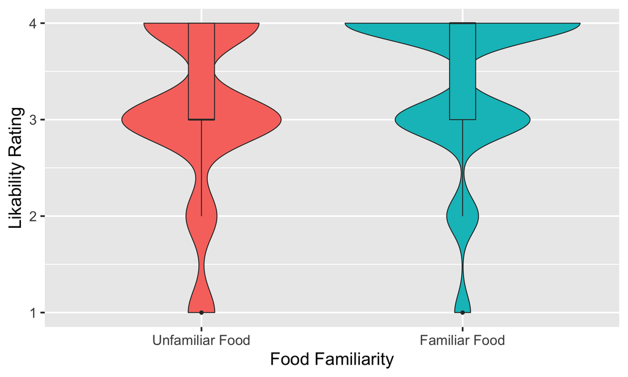

```r
#Graph it
plot2 <- ggplot(data = data,
                  aes(x = FamUnfamFood,
                      y = ratings,
                      fill =FamUnfamFood)) +
  labs(x = "Food Familiarity", y = "Likability Rating") +
  scale_x_discrete(labels = c("Unfamiliar Food","Familiar Food" )) +

  theme_grey(base_size = 20) +
  guides(fill=F)+
  geom_violin(position=position_dodge(.9))+
  geom_boxplot(position=position_dodge(.9),
               width=.1)
plot2
```

### Prediction 2.2

In order to try to minimize the confounds from prediction 2, we will look at how food familiarity influences likability rating within Suriname only.

For prediction 2.2 we fail to reject the null hypothesis as there is not a significant effect between food familiarity and likability rating for Suriname. This suggests that when a person from an unknown country is shown eating a familiar, or unfamiliar food it doesn’t significantly influence a child’s general liking towards them.

```r
p2.2<-aov(ratings~FamUnfamFood+Error(pid),data = data[data$GroupCountryFam==0,])
summary(p2.2)
```

```
##
## Error: pid
##              Df Sum Sq Mean Sq
## FamUnfamFood  1  6.281   6.281
##
## Error: Within
##               Df Sum Sq Mean Sq F value Pr(>F)
## FamUnfamFood   1    0.6  0.5689   0.789  0.375
## Residuals    464  334.6  0.7211
```

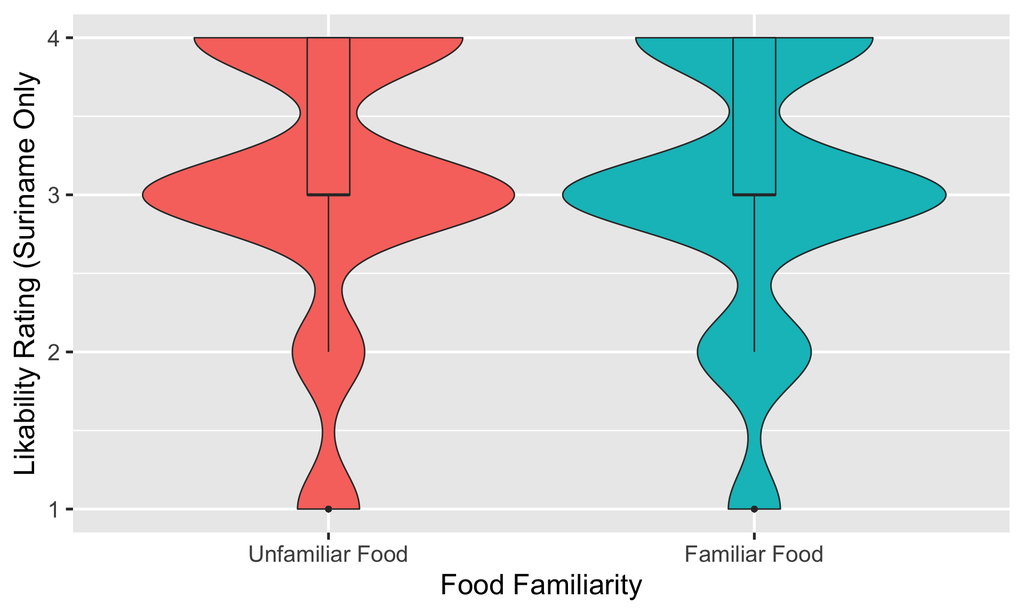

```r
#Graph it
plot2.2 <- ggplot(data = data[data$GroupCountryFam==0,],
                  aes(x = FamUnfamFood,
                      y = ratings,
                      fill =FamUnfamFood)) +
  labs(x = "Food Familiarity", y = "Likability Rating (Suriname Only") +
  scale_x_discrete(labels = c("Unfamiliar Food","Familiar Food" )) +

  theme_grey(base_size = 20) +
  guides(fill=F)+
  geom_violin(position=position_dodge(.9))+
  geom_boxplot(position=position_dodge(.9),
               width=.1)
plot2.2
```

## Prediction 3 Analysis

For prediction 3 we fail to reject the null hypothesis, meaning that there was no significant change in the Pre to Post test ratings after the unfamiliar country was paired with either a familiar or unfamiliar food.This indicates that children opinions don’t seem to change after learning that people eat familiar foods.

```r
p3<-aov(ratings~prePosttest*FamUnfamFood+Error(pid),data=data)
summary(p3)
```

```
##
## Error: pid
##             Df Sum Sq Mean Sq
## prePosttest  1  5.773   5.773
##
## Error: Within
##                           Df Sum Sq Mean Sq F value   Pr(>F)
## prePosttest                1    0.3   0.345    0.53    0.467
## FamUnfamFood               1   17.1  17.090   26.27 3.61e-07 ***
## prePosttest:FamUnfamFood   1    0.1   0.149    0.23    0.632
## Residuals                929  604.4   0.651
## ---
## Signif. codes:  0 '***' 0.001 '**' 0.01 '*' 0.05 '.' 0.1 ' ' 1
```

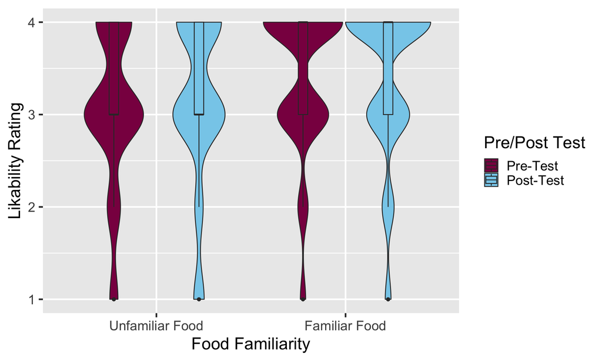

```r
#graph it
plot3 <- ggplot(data = data,
                  aes(x = FamUnfamFood,
                      y = ratings,
                      fill =prePosttest)) +
  labs(x = "Food Familiarity", y = "Likability Rating",fill="Pre/Post Test") +
  scale_x_discrete(labels = c("Unfamiliar Food","Familiar Food" )) +
   scale_fill_manual(values=c("deeppink4","skyblue"),
                    labels=c("Pre-Test","Post-Test"))+

  theme_grey(base_size = 20) +
  geom_violin(position=position_dodge(.9))+
  geom_boxplot(position=position_dodge(.9),
               width=.1)
plot3
```

#### Prediction 3.2 For prediction 3.2 we made a more specific plot to see the differences in pre/post test ratings within each individual country. We don’t see significant changes in the ratings after children learned that Suriname either ate familiar or unfamiliar foods.

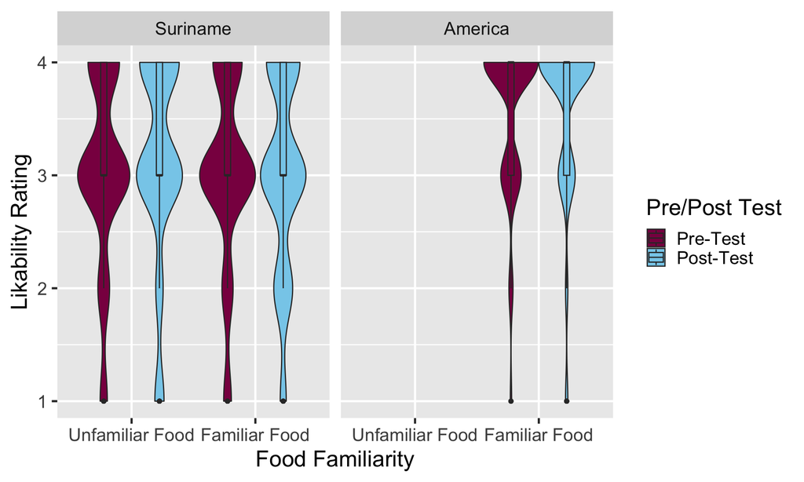

```r
plot3.2 <- ggplot(data = data,
                  aes(x = FamUnfamFood,
                      y = ratings,
                      fill =prePosttest)) +
  labs(x = "Food Familiarity", y = "Likability Rating",fill="Pre/Post Test") +
  scale_x_discrete(labels = c("Unfamiliar Food","Familiar Food" )) +
   scale_fill_manual(values=c("deeppink4","skyblue"),
                    labels=c("Pre-Test","Post-Test"))+

  theme_grey(base_size = 20) +
  geom_violin(position=position_dodge(.9))+
  geom_boxplot(position=position_dodge(.9),
               width=.1)+
  facet_wrap(~factor(GroupCountryFam,labels=c("Suriname","America")))
plot3.2
```

```r
ggsave("plot3.2.tiff",plot3.2,width=10,height=6,units="in",dpi=150)
```